# Machine Learning

### Improving the model

1. We will first take all the variables in cars data set and develop a regression model, this will be our full model.
2. We do Partial F-test to compare full model with our previous model from part 2 and see if the new variables add any significance.
3. If the full model is significant, we will run Stepwise regression to come up with the best model using a p-value of 0.05.
4. We will run regression diagnostics and check model validity and arrive at the final model.

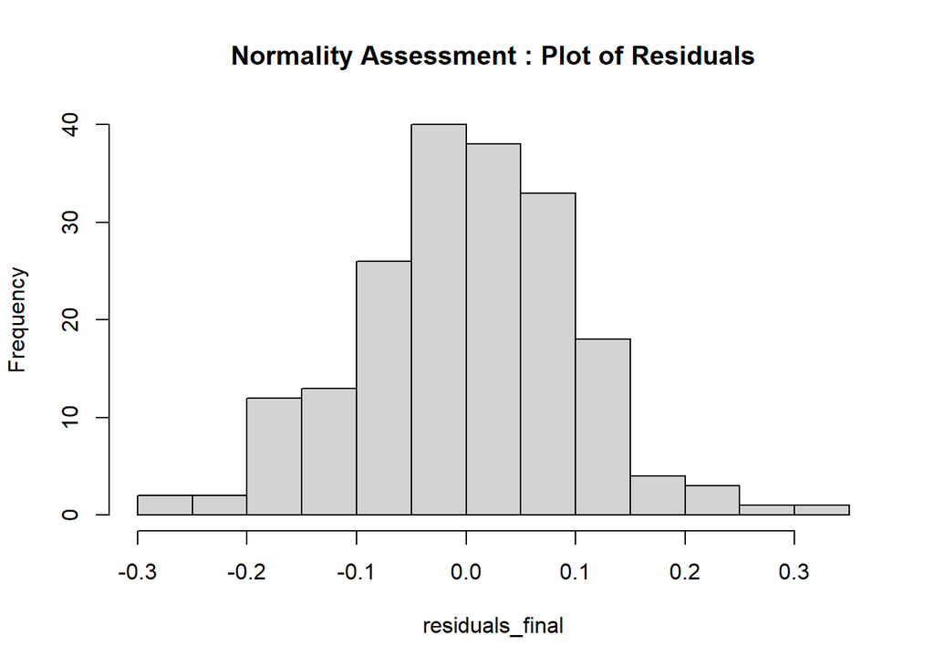

```r
# add log price to main data set
cars$ln_price <- log(cars$price)

# make a subset
cars1 <- cars[,-24]

# full model
fm <- lm(ln_price ~ ., data = cars1)

# partial f-test
anova(rm, fm)

# step wise regression
k <- olsrr::ols_step_both_p(fm, prem = 0.05, pent = 0.05, details = TRUE)

# variables
cw <- cars$curb_weight
height <- cars$height
wb <- cars$wheel_base
el <- cars$engine_location


# final model
final_model <- lm(ln_price ~ cw + make + hp + bs + height + wb + asp + el)
summary(final_model)

residuals_final <- residuals(final_model)
residuals.final_sq <- residuals_final^2
predict_final <- predict(final_model)
predict_final_sq <- predict_final^2

# Multi Collinearity
print("Checking for Multi-Collinearity")
car::vif(final_model)

# Normality Assessment
hist(residuals_final, main = "Normality Assessment : Plot of Residuals") ## informal
```

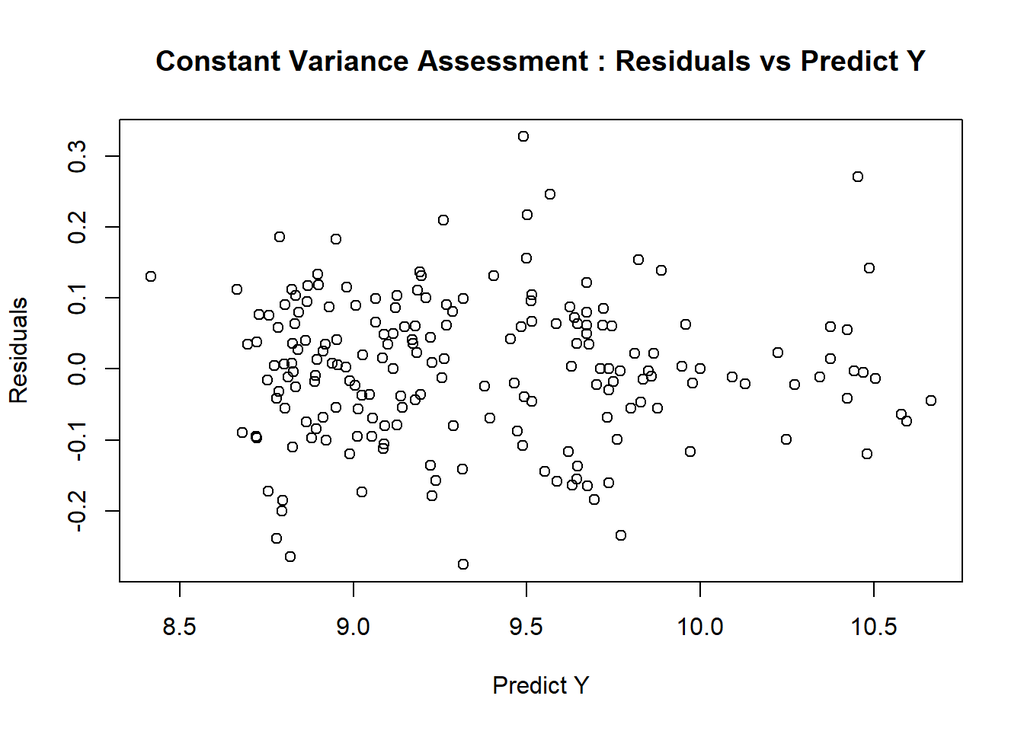

```r
nortest::ad.test(residuals(final_model)) ## formal

# Constant Variance Assessment
plot(predict_final, residuals_final, xlab = "Predict Y", ylab = "Residuals", main = "Constant Variance Assessment : Residuals vs Predict Y")
```

[figure not shown]

```
## Analysis of Variance Table
##
## Model 1: ln_price ~ hp + ft + asp + nod + bs + dw + make + cm + len
## Model 2: ln_price ~ make + fuel_type + aspiration + num_of_doors + body_style +
##     drive_wheels + engine_location + wheel_base + length + width +
##     height + curb_weight + engine_type + num_of_cylinders + engine_size +
##     fuel_system + bore + stroke + compression_ratio + horsepower +
##     peak_rpm + city_mpg + highway_mpg
##   Res.Df    RSS Df Sum of Sq      F    Pr(>F)
## 1    160 2.5350
## 2    140 1.6026 20   0.93245 4.0729 3.679e-07 ***
## ---
## Signif. codes:  0 '***' 0.001 '**' 0.01 '*' 0.05 '.' 0.1 ' ' 1
## Stepwise Selection Method
## ---------------------------
##
## Candidate Terms:
##
## 1. make
## 2. fuel_type
## 3. aspiration
## 4. num_of_doors
## 5. body_style
## 6. drive_wheels
## 7. engine_location
## 8. wheel_base
## 9. length
## 10. width
## 11. height
## 12. curb_weight
## 13. engine_type
## 14. num_of_cylinders
## 15. engine_size
## 16. fuel_system
## 17. bore
## 18. stroke
## 19. compression_ratio
## 20. horsepower
## 21. peak_rpm
## 22. city_mpg
```

[output cut: 966 more lines]

```
## [1] "Checking for Multi-Collinearity"
##              GVIF Df GVIF^(1/(2*Df))
## cw      13.293771  1        3.646062
## make   165.711299 20        1.136276
## hp       6.981155  1        2.642188
## bs       6.032967  4        1.251891
## height   4.453067  1        2.110229
## wb       8.200605  1        2.863670
## asp      1.561430  1        1.249572
## el       4.828124  1        2.197299
##
##  Anderson-Darling normality test
##
## data:  residuals(final_model)
## A = 0.38992, p-value = 0.3795
```

```r
# Independence Assessment
### Graphical - Residuals(t) versus Residuals(t-1)
lag.plot(residuals_final, lags = 1, do.lines = FALSE,
         diag = FALSE,
         main = "Independence Assessment : Residuals versus Lag 1 Residuals")
abline(h=0, v=0)
```

Partial F-test:  
H_{0} : beta_{i} = 0  
H_{1} : At least one beta_{i} =/= 0  
We see the p-value in partial f-test is ~0 which means it is statistically significant. This implies that full model has newer variables which add significance to the inital model.

Stepwise Regression:  
After stepwise regression using all the variables, we arrive at the following set of independent variables : curb_weight, make, horsepower, body_style, height, wheel_base, aspiration and engine_location.

From business point of view it makes sense to include mileage also. But here horsepower is highly correlated to city and highway mileage, so that is accounted.  
Dimensions of the car also matter. Height is there in the variable set and length & width are highly correlated with curb_weight.  
Body style, aspiration and make - these are the attributes of car on which price is dependent.

Regression diagnostics results:  
Multicollinearity : Not present as all the values of normalized gvif(last column in vif output) are less than 5.  
Normality - the residuals are normally distributed as seen from the plot of residuals and ad test. Constant variance (homoscedasticity) : We see from the plot, that there are no patterns which implies this condition is satisfied.  
Independence : From this plot also we see no patterns, which implies this condition is satisfied.

Final Model : The final model has an adjusted r-squared value of ~95% and is valid as per global f-test(p-value ~ 0).  
1 unit increment in curb weight leads to increase of 0.00054% in price assuming all other variables constant.  
Depending on the make of the car, price increase or decrease assuming all other variables constant.  
1 unit increase in horsepower leads to increase of 0.001956% in price assuming all other variables constant.  
1 unit increase in height leads to decrease in price by 0.03008% assuming all other variables constant.  
1 unit increase in wheel base leads to increase of 0.01573% in price assuming all other variables constant.  
Depending on the body syle of car, price may increase or decrease.  
Turbo cars are on avg more expensive by 0.078% assuming all other variables constant.  
Cars with engine at the rear are on avg more expensive by 0.349% assuming all other variables constant.

### Controlling the FDR in variables with a q of 0.1 using BH procedure

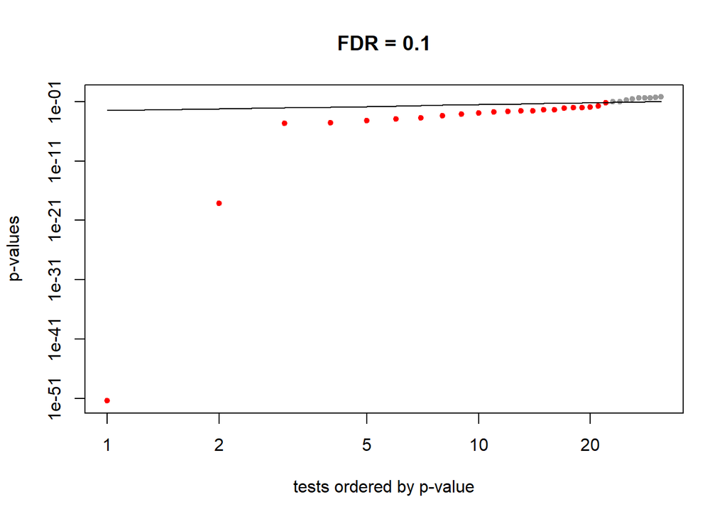

```
##            variables      p_value rank_p label
## 1        (Intercept) 3.935363e-52      1  TRUE
## 2                 cw 8.139430e-19      2  TRUE
## 3             height 2.408899e-05      3  TRUE
## 4                 wb 2.865527e-05      4  TRUE
## 5     makemitsubishi 6.941446e-05      5  TRUE
## 6            makebmw 1.129921e-04      6  TRUE
## 7        bshatchback 1.868136e-04      7  TRUE
## 8                 hp 4.534875e-04      8  TRUE
## 9       makeplymouth 8.456318e-04      9  TRUE
## 10           bswagon 1.134995e-03     10  TRUE
## 11         makedodge 2.052322e-03     11  TRUE
## 12          aspturbo 2.442097e-03     12  TRUE
## 13           bssedan 2.803320e-03     13  TRUE
## 14        makepeugot 2.869208e-03     14  TRUE
```

[output cut: 18 more lines]

```r
# get p-values
p_value_table <- as.data.frame(summary(final_model)$coefficients[,4])
p_value_table$variables <- rownames(p_value_table)
rownames(p_value_table) <- NULL
colnames(p_value_table) <- c('p_value', 'variables')

# rank p-values
p_value_table <- p_value_table %>% mutate(rank_p = rank(p_value, ties.method = 'min'))

# BH metric
p_value_table$bh <- 0.1 * p_value_table$rank_p / nrow(p_value_table)

# Checking if p-value is less than BH metric
p_value_table$label <- ifelse(p_value_table$p_value <= p_value_table$bh, TRUE, FALSE)
p_value_table[,c(2,1,3,5)] %>% arrange(rank_p)

# Taking the subset of p-values
subset_p <- p_value_table[p_value_table$label == TRUE,]

## FDR function - extract p-value cutoff for E[fdf] < q
fdr <- function(pvals, q, plotit=FALSE){
  pvals <- pvals[!is.na(pvals)]
  N <- length(pvals)

  k <- rank(pvals, ties.method="min")
  alpha <- max(pvals[ pvals <= (q*k/N) ])

  if(plotit){
    sig <- factor(pvals <= alpha)
    o <- order(pvals)
    plot(pvals[o], log="xy", col=c("grey60","red")[sig[o]], pch=20,
      ylab="p-values", xlab="tests ordered by p-value", main = paste('FDR =',q))
    lines(1:N, q*(1:N) / N)
  }

  return(alpha)
}

# BHvalue for cutoff and plot
fdr(p_value_table$p_value, 0.1, plotit = TRUE)
```

In our improved model, we want to minimize FDR. We started with q of 0.1 and used Benjamini-Hochberg procedure to check p-values.  
We got a cut-off of 0.06734374 for p-values, which implies to keep the fdr <= 0.1, we should consider variables with p-value less than or equal to 0.06734374.  
Using this cut-off value, we were able to reduce the number of variables from 31 to 22. We can see from the table, some of the “make…” variables are above the p-value cut-off and are in the rejection region.  
Now our fdr is less than or equal to 0.1, which means number of false positives is less than or equal to 2.2 in 22 variables. This implies we should have 20 true discoveries in our model.